# 9_Matplotlib y Seaborn

# 2 .plot()

Múltiples parámetros ´´´text plt.plot(x, y, style, label, linewidth=1, alpha=1) ´´´

- ‘style’: cadena de texto con formato (color, tipo…) [color][marker][line]
- ‘label’: referencia para leyenda
- ‘linewidth’: brocha
- ‘alpha’: transparencia

Otros: https://matplotlib.org/stable/api/_as_gen/matplotlib.pyplot.plot.html

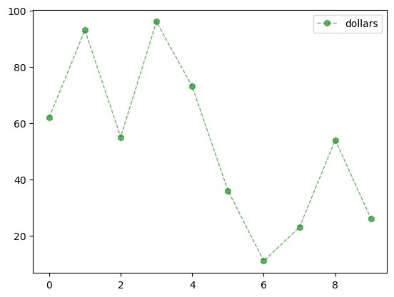

```python
y_data = np.random.randint(100,size=(10))
x_data = np.arange(10)
fig,axis = plt.subplots(1,1)
axis.plot(x_data,y_data,'gh--',label='dollars',linewidth=1,alpha=0.6) #␣creación del gráfico
axis.legend(loc='best') # representar la leyenda
plt.show()
```

| Color | Descripción |
| --- | --- |
| **b** | Blue (Azul) |
| **g** | Green (Verde) |
| **r** | Red (Rojo) |
| **c** | Cyan (Cian) |
| **m** | Magenta (Magenta) |
| **y** | Yellow (Amarillo) |
| **k** | Black (Negro) |
| **w** | White (Blanco) |

| Marcador | Descripción |
| --- | --- |
| **.** | Point marker |
| **,** | Pixel marker |
| **o** | Circle marker |
| **v** | Triangle_down marker |
| **^** | Triangle_up marker |
| **<** | Triangle_left marker |
| **>** | Triangle_right marker |
| **1** | Tri_down marker |
| **2** | Tri_up marker |
| **3** | Tri_left marker |
| **4** | Tri_right marker |
| **s** | Square marker |
| **p** | Pentagon marker |
| * | Star marker |
| **h** | Hexagon1 marker |
| **H** | Hexagon2 marker |
| **+** | Plus marker |
| **x** | X marker |
| **D** | Diamond marker |
| **d** | Thin_diamond marker |
| **_** | Hline marker |

| Línea | Descripción |
| --- | --- |
| **-** | Solid line style (Línea continua) |
| **--** | Dashed line style (Línea discontinua) |
| **-.** | Dash-dot line style (Línea punto-raya) |
| **:** | Dotted line style (Línea punteada) |

## 2.0.1 Representar más de un gráfico en una subfigura

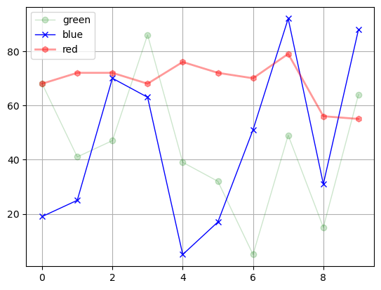

```python
x_data = np.arange(10)
fig,axis = plt.subplots(1,1)
axis.plot(x_data,np.random.randint(100,size=(10)),'go-',label='green',linewidth=1,alpha=0.2) # creación␣del gráfico
axis.plot(x_data,np.random.randint(100,size=(10)),'bx-',label='blue',linewidth=1) # creación del gráfico
axis.plot(x_data,np.random.randint(50,80,size=(10)),'rh-',label='red',linewidth=2, alpha=0.4) # creación del gráfico
axis.legend(loc='best')
plt.grid()
plt.show()
```

## 2.1 Decoradores

Cambian el aspecto general de la figura

- axes.set_xticks() #etiquetas del eje
- axes.set_title(‘titulo’) #titulo
- axes.set_ylabel(‘label’)
- axes.set_frame_on(bool)

[Más métodos](https://matplotlib.org/stable/api/axes_api.html)

## 3 Anotaciones

Formas de añadir información sobre el gráfico

- axes.text(x,y,’texto’)
- axes.annotate(texto, xy, xytext, xycoords, arrowprops)

[Más métodos](https://matplotlib.org/stable/users/explain/text/annotations.html)

```python
y_data = np.random.randint(100, size=(10)) # Cuidado con las dimensiones␣absolutas
x_data = np.arange(10)
```

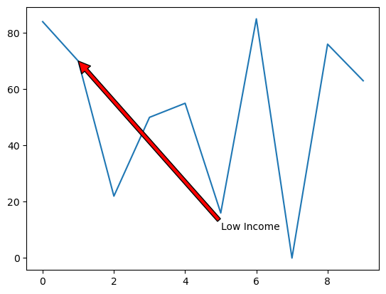

```python
fig,axis = plt.subplots(1,1)
axis.plot(x_data,y_data)
# axis.text(x_data[1],y_data[1],'Low income') # coordenadas igual a los datos
axis.annotate('Low Income', xy=(x_data[1],y_data[1]), xytext=(5, 10),arrowprops = dict(facecolor='red', shrink=1.0)) # anotación completa
plt.show()
```

# 4 Tipos de gráficos

Ejemplos disponibles como referencia https://matplotlib.org/stable/api/_as_gen/matplotlib.pyplot.subplots.htm

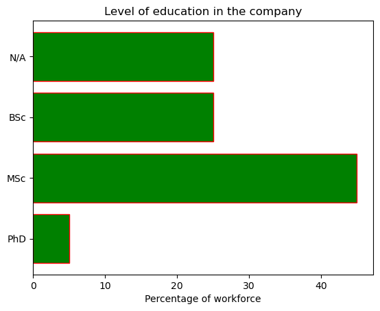

```python
# Horizontal bar
fig, ax = plt.subplots()
# Example data
people = ('PhD', 'MSc', 'BSc', 'N/A')
y_pos = np.arange(len(people))
percentage = [5,45,25,25]

# print(y_pos)
ax.barh(y_pos, percentage, align='center',
    color='green', edgecolor='red')

ax.set_yticks(y_pos)
ax.set_yticklabels(people)
#ax.invert_yaxis() # labels read top-to-bottom
ax.set_xlabel('Percentage of workforce')
ax.set_title('Level of education in the company')
plt.show()
```

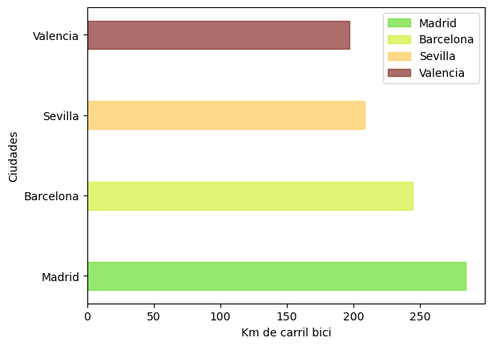

```python
ls_count = (284487, 244560, 208493, 196764)
cities = ('Madrid', 'Barcelona', 'Sevilla', 'Valencia')
data = np.array(ls_count)/1000
y_pos = np.arange(data.size)

width = 0.35 # the width of the bars
opacity = 0.7

fig, ax = plt.subplots()
rects1 = ax.barh(y_pos, data, width, alpha=opacity)

rects1[3].set_color('#872f29')
rects1[2].set_color('#ffcb59')
rects1[1].set_color('#d6ee39')
rects1[0].set_color('#6ade30')

ax.set_yticks(y_pos)
ax.set_yticklabels(cities)

# add some text for labels, title and axes ticks
ax.set_ylabel('Ciudades')
ax.set_xlabel('Km de carril bici')

ax.legend((rects1[0], rects1[1], rects1[2], rects1[3]), cities)

plt.show()
```

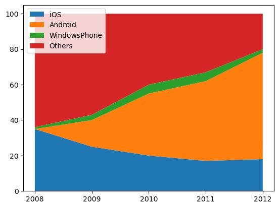

```python
# stack plot
x = [2008, 2009, 2010, 2011, 2012]
iOS = [35, 25, 20, 17, 18]
Android = [0, 15, 35, 45, 60]
WindowsPhone = [1, 3, 5, 5, 2]
Others = [64,57,40,33,20]

# y = np.vstack([iOS, Android, WindowsPhone,Others])
# print(y)
labels = ["iOS ", "Android", "WindowsPhone", "Others"]

fig, ax = plt.subplots()
ax.stackplot(x, iOS, Android, WindowsPhone, Others,labels=labels)
# ax.stackplot(x, y, labels=labels)
ax.set_xticks(x)
ax.legend(loc='upper left')
plt.show()
```

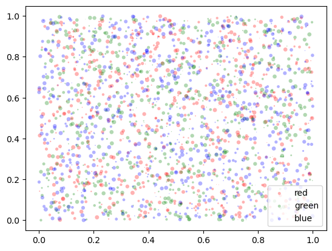

```python
# Scatter plot
from numpy.random import rand
fig, ax = plt.subplots()
n = 700
for color in ['red', 'green', 'blue']:
    x, y = rand(2, n)
    scale = 25.0 * rand(n)
    ax.scatter(x, y, c=color, s=scale, label=color,
        alpha=0.3, edgecolors='none')
ax.legend()
plt.show()
```

# 4.1 Grabar a archivo

figure.savefig(,dpi=None, facecolor=’w’, edgecolor=’w’, format=None, bbox_inches=None)

```python
# guardar la figura (puede ser múltiples gráficos)
import os
ruta = os.path.join("res", "o_figure.png")
fig.savefig(ruta, format='png') # varios formatos aceptados (‘pdf’,’ png’,‘svg’, ‘eps’...)
```

# 5 Representación gráfica en pandas

- pandas ofrece interfaz para dibujar Series y DataFrame
- Usa matplotlib internamente
- Fácil de usar

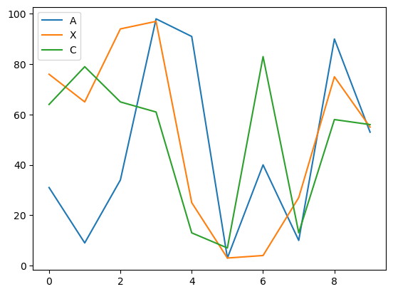

|  | A | X | C |
| --- | --- | --- | --- |
| 0 | 31 | 76 | 64 |
| 1 | 9 | 65 | 79 |
| 2 | 34 | 94 | 65 |
| 3 | 98 | 97 | 61 |
| 4 | 91 | 25 | 13 |
| 5 | 3 | 3 | 7 |
| 6 | 40 | 4 | 83 |
| 7 | 10 | 27 | 13 |
| 8 | 90 | 75 | 58 |
| 9 | 53 | 55 | 56 |

```python
rand_matrix = np.random.randint(100,size=(10,3))
frame = pd.DataFrame(rand_matrix, columns=list('AXC'))
frame.plot()
plt.show() # aún es necesario llamar a show() para mostrar los gráficos //TODO␣encontrar una manera de no usar plt desde pandas
display(frame) # datos en eje x, eje y, leyenda, series?
```

# 6 frame.plot()

frame.plot(x,y,label=,ax,style,kind,xticks,yticks,title,subplots)

- (solo para Series) label: referencia para la leyenda
- ax: subfigura en la que dibujar los datos
- style: estilo de la línea
- kind: tipo de gráfico (’bar’, ‘pie’, ‘hist’, ‘area’ ‘line’, ‘barh’, ‘density’, ‘kde’).
- xticks y yticks: valores en los ejes X e Y
- title: string como título
- (solo para DataFrame) subplots: bool si se desean subfiguras separadas para cada columna.
- (solo para DataFrame) ‘x’ e ‘y’ se pueden utilizar para seleccionar columnas para cada eje [Lista completa](https://pandas.pydata.org/pandas-docs/stable/reference/api/pandas.DataFrame.plot.html) de argumentos

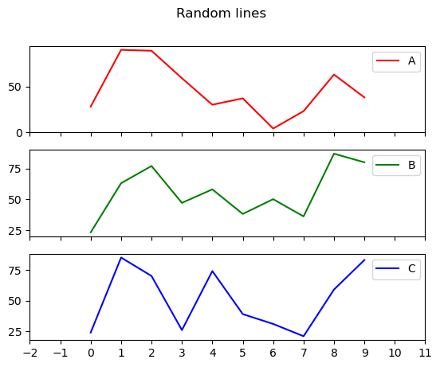

|  | A | B | C |
| --- | --- | --- | --- |
| 0 | 28 | 23 | 24 |
| 1 | 90 | 63 | 85 |
| 2 | 89 | 77 | 70 |
| 3 | 59 | 47 | 26 |
| 4 | 30 | 58 | 74 |
| 5 | 37 | 38 | 39 |
| 6 | 4 | 50 | 31 |
| 7 | 23 | 36 | 21 |
| 8 | 63 | 87 | 59 |
| 9 | 38 | 80 | 83 |

```python
rand_matrix = np.random.randint(100, size=(10,3))
frame = pd.DataFrame(rand_matrix, columns=list('ABC'))
frame.plot(style=['r-','g-','b-'], xticks=range(-2,12), title='Random lines',subplots=True)
plt.show()
display(frame)
```

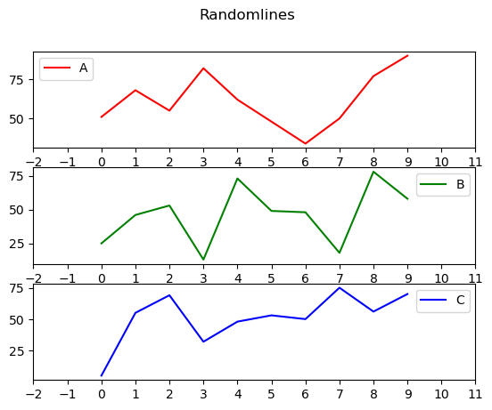

```python
# combinar pandas plot con matplotlib
rand_matrix = np.random.randint(100, size=(10,3))
frame = pd.DataFrame(rand_matrix, columns=list('ABC'))
fig, axis = plt.subplots(3,1)
ax = frame.plot(style=['r-','g-','b-'], xticks=range(-2,12), title='Randomlines', subplots=True, ax=axis)
ax[0].legend(loc='upper left')
plt.show()
```

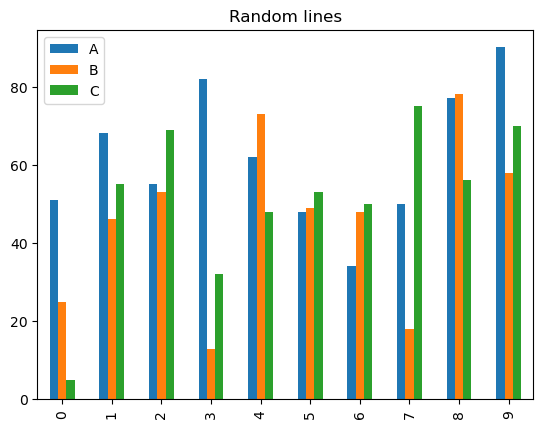

```python
# Gráfico de barras
frame.plot(kind='bar', title='Random lines')
plt.show()
```

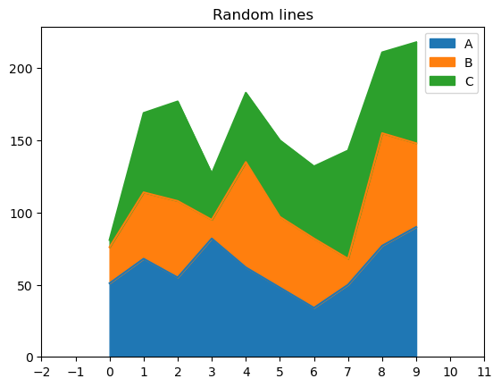

```python
# Gráfico de área
frame.plot(kind='area', xticks=range(-2,12), title='Random lines')
plt.show()
```

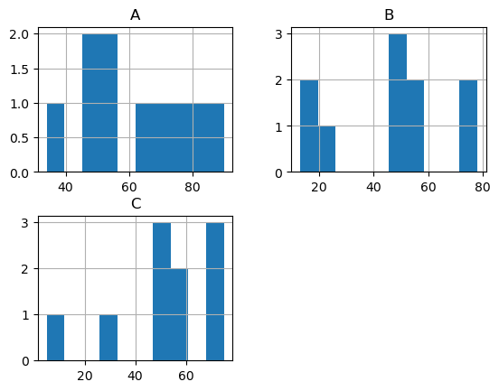

```python
# Histogramas
frame.hist()
plt.show()
```

|  | mass | radius |
| --- | --- | --- |
| Mercury | 0.33 | 2439.7 |
| Venus | 4.87 | 6051.8 |
| Earth | 5.97 | 6378.1 |

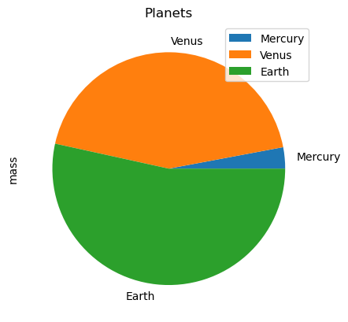

```python
# Gráfico de pastel
df = pd.DataFrame({'mass': [0.330, 4.87 , 5.97],
                    'radius': [2439.7, 6051.8, 6378.1]},
                    index=['Mercury', 'Venus', 'Earth'])
display(df)
df.plot(y='mass', kind='pie', title='Planets') # y variable a usar
plt.show()
```

# 7 Seaborn

- Abstracción de matplotlib
- Facilidad de uso y personalización
- Excelente para exploración y visualización de relaciones entre variables Viene con varios datasets predefinidos https://github.com/mwaskom/seaborn-data Documentación [oficial](https://seaborn.pydata.org/api.html)

```python
import seaborn as sns
```

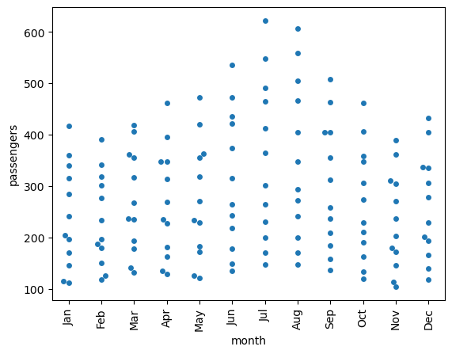

```python
# Load data
flights_data = sns.load_dataset("flights")
# display(flights_data)

# Construct plot
sns.swarmplot(x="month", y="passengers", data=flights_data)
# Show plot
plt.xticks(rotation=90)
plt.show()
```

**Compatible con pandas**

```python
# Load in data
tips = pd.read_csv("https://raw.githubusercontent.com/mwaskom/seaborn-data/master/tips.csv")
tips.sample(5)
```

|  | total_bill | tip | sex | smoker | day | time | size |
| --- | --- | --- | --- | --- | --- | --- | --- |
| 17 | 16.29 | 3.71 | Male | No | Sun | Dinner | 3 |
| 233 | 10.77 | 1.47 | Male | No | Sat | Dinner | 2 |
| 77 | 27.20 | 4.00 | Male | No | Thur | Lunch | 4 |
| 205 | 16.47 | 3.23 | Female | Yes | Thur | Lunch | 3 |
| 226 | 10.09 | 2.00 | Female | Yes | Fri | Lunch | 2 |

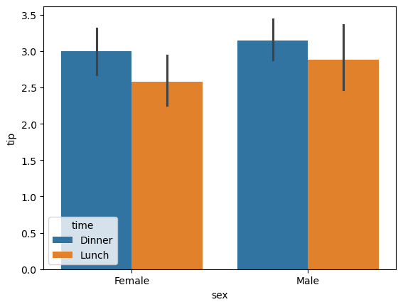

```python
sns.barplot(x='sex', y='tip', hue='time', data=tips) # palette para color␣(negro desviacion)
plt.show()
```

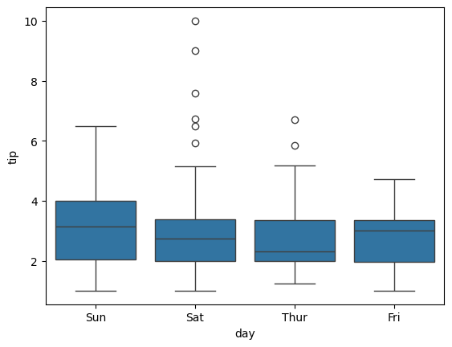

```python
# Boxplot (cuartiles)
sns.boxplot(x='day', y='tip', data=tips)
# sns.boxplot(x=tips['day'], y=tips.tip)
plt.show()
```

# 7.1 Relaciones entre variables

sns.relplot()

```python
tips = sns.load_dataset("tips")
tips.sample(5)
```

|  | total_bill | tip | sex | smoker | day | time | size |
| --- | --- | --- | --- | --- | --- | --- | --- |
| 73 | 25.28 | 5.00 | Female | Yes | Sat | Dinner | 2 |
| 160 | 21.50 | 3.50 | Male | No | Sun | Dinner | 4 |
| 120 | 11.69 | 2.31 | Male | No | Thur | Lunch | 2 |
| 33 | 20.69 | 2.45 | Female | No | Sat | Dinner | 4 |
| 242 | 17.82 | 1.75 | Male | No | Sat | Dinner | 2 |

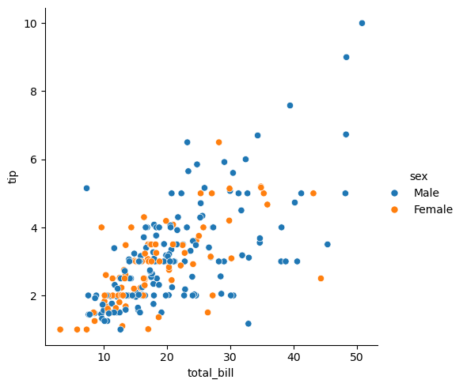

```python
sns.relplot(x='total_bill', y='tip', hue='sex', data=tips, kind='scatter')
plt.show()
```

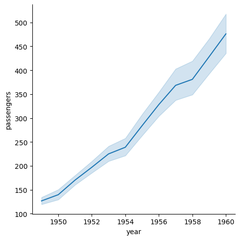

```python
 # representar la media y la variación de una variable en función de otra
data = sns.load_dataset('flights')
sns.relplot(x="year", y="passengers", kind="line", data=data)
plt.show()
```

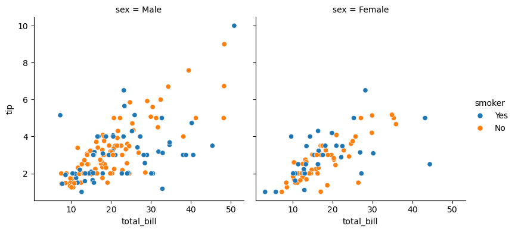

```python
# relacionar hasta 4 variables automáticamente
sns.relplot(x="total_bill", y="tip", hue="smoker",
            col="sex", height=4,
            kind="scatter",data=tips); #kind ('line','scatter'...)
plt.show()
```

# 7.2 Distribución de un dataset

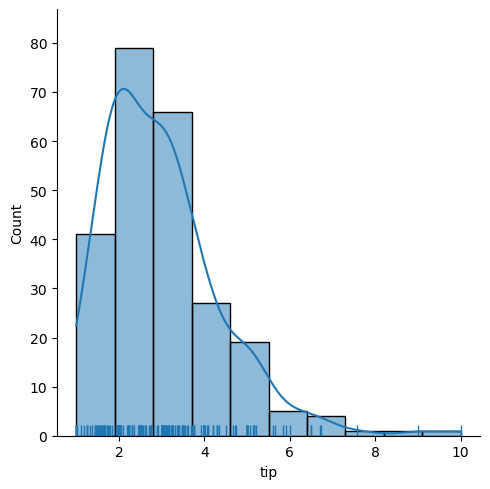

```python
# histograma y density plot
# kde = gaussian kernel density estimate, linea de densidad
# bins = tamaño de los contenedores
# rug = densidad de los datos
sns.displot(tips['tip'], kde=True, bins=10, rug=True)
plt.show()
```

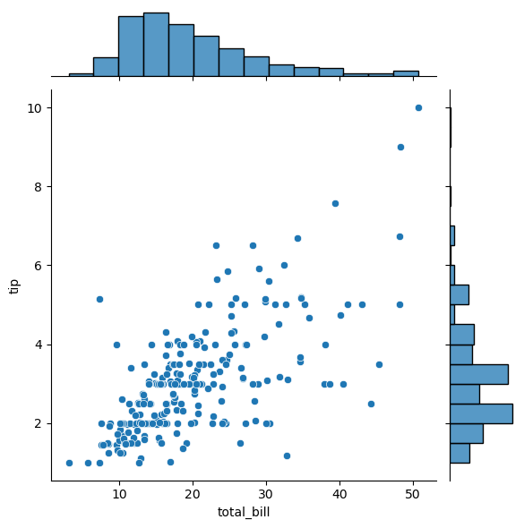

```python
# Distribución bi-variable
sns.jointplot(x='total_bill', y='tip', data=tips)
plt.show()
```

|  | sepal_length | sepal_width | petal_length | petal_width | species |
| --- | --- | --- | --- | --- | --- |
| 0 | 5.1 | 3.5 | 1.4 | 0.2 | setosa |
| 1 | 4.9 | 3.0 | 1.4 | 0.2 | setosa |
| 2 | 4.7 | 3.2 | 1.3 | 0.2 | setosa |
| 3 | 4.6 | 3.1 | 1.5 | 0.2 | setosa |
| 4 | 5.0 | 3.6 | 1.4 | 0.2 | setosa |

```
array(['setosa', 'versicolor', 'virginica'], dtype=object)
```

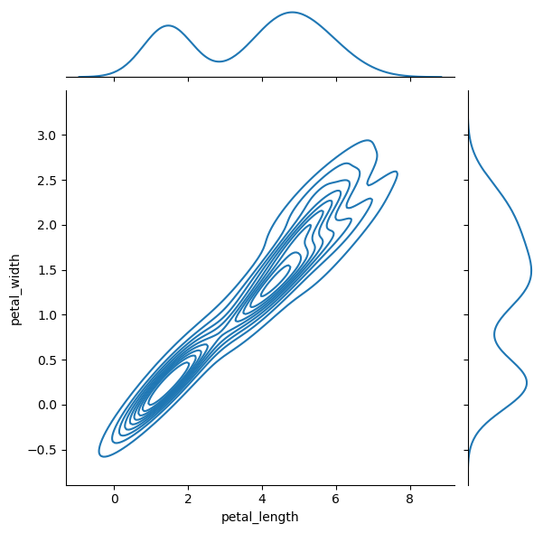

```python
# Density plot bi-variable
iris = sns.load_dataset('iris')
display(iris.head(5))
display(iris["species"].unique())
sns.jointplot(x='petal_length', y='petal_width', kind="kde", data=iris)
plt.show()
```

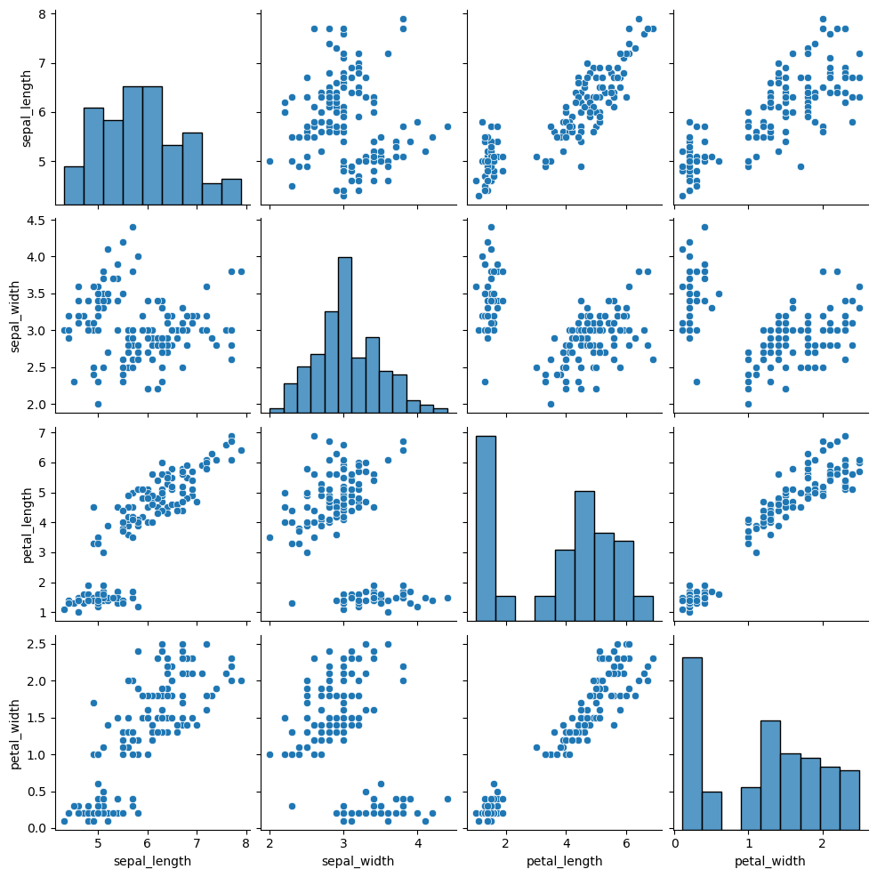

```python
# Relación de cada pareja
sns.pairplot(iris)
plt.show()
```

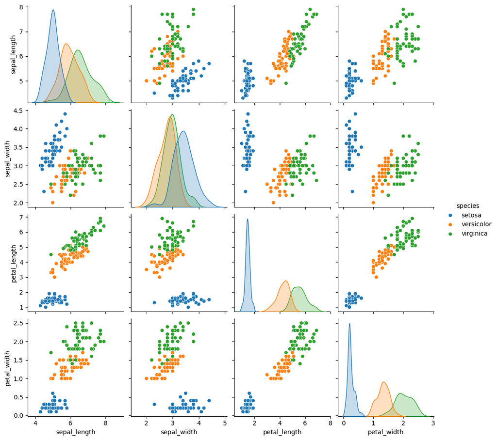

```python
# Relación de cada pareja
sns.pairplot(iris, hue = "species")
plt.show()
```

[figure not shown]

```python
#scatter de clases, coloreando segun clase en matplotlib
iris = sns.load_dataset('iris')

# preparacion de los datos
data = []
colors = ["red", "green", "blue"]
groups = ["setosa", "versicolor", "virginica"]
columns = ["petal_length", "petal_width"]
for i in groups:
    # busqueda por clase definida
    data.append(iris[iris["species"] == i][columns].values)

#creacion de la grafica
fig = plt.figure()
ax = fig.add_subplot()
for count, d in enumerate(data):
    # separar las variables del grafico
    x, y = d[:,0], d[:,1]
    ax.scatter(x, y, alpha = 0.4, c = colors[count -1], edgecolors = 'none', s= 30, label = groups[count - 1])

#etiquetas
ax.set_xlabel(columns[0])
ax.set_ylabel(columns[1])
plt.legend(loc='best')
plt.title('Matplot scatter plot')
plt.show()
```